### PART A

1. Regression model with weekly wages as the response and years of education and experience as predictors.

```
##
## Call:
## lm(formula = wage ~ educ + exper, data = uswages2)
##
## Residuals:
##     Min      1Q  Median      3Q     Max
## -1014.7  -235.2   -52.1   150.1  7249.2
##
## Coefficients:
##              Estimate Std. Error t value Pr(>|t|)
## (Intercept) -239.1146    50.7111  -4.715 2.58e-06 ***
## educ          51.8654     3.3423  15.518  < 2e-16 ***
## exper          9.3287     0.7602  12.271  < 2e-16 ***
## ---
## Signif. codes:  0 '***' 0.001 '**' 0.01 '*' 0.05 '.' 0.1 ' ' 1
##
## Residual standard error: 426.8 on 1964 degrees of freedom
## Multiple R-squared:  0.1348, Adjusted R-squared:  0.1339
## F-statistic:   153 on 2 and 1964 DF,  p-value: < 2.2e-16
```

```
## [1] 0.134793
```

3. The *case number* is **1550**, and the *residual value* belonging to this case number is **7249.174**.

```r
#Case number
which.max(lmodsum$residuals)
```

```
## 15387
##  1550
```

```r
#Max residual
max(lmodsum$residuals)
```

```
## [1] 7249.174
```

4. The mean is close to zero, whereas the median is close to -52.14. This leads us to conclude that the distribution of the residuals is **skewed right** given the mean is bigger than the medians. In addition, in general incomes tend to have a right skewed distribution, where the majority make little/average money, and a few ones make very high profits. Also, one of the assumptions when using RSS is that the mean of the errors (residuals) is zero. Altough, in theory the errors should be exactly zero, in reality it will always be a bit more (or less) that zero.

```
## [1] -1.381535e-15
```

```
## [1] -52.14337
```

5. For two people with the same education and one year difference in experience, the model suggests a difference in predicted weekly wages of **$9.33**.
6. The *correlation* of fitted values is approximately **zero**.

```r
#Correlation
cor(lmod$residuals, lmod$fitted.values)
```

```
## [1] 6.35678e-17
```

6. Geometrically speaking, a correlation of zero hints at **orthogonality**. Orthogonality simply means that the two vecotrs are perpendicular to one another (form a 90 degree angle). In Figure one, we are able to see the plot of the residuals vs the fitted. Next to it (right), we are able to see the theoretical geometric reppresentation and indeed, our correlation of zero, is able to prove that the fitted values (y^) are orthogonal with the residuals (e^).

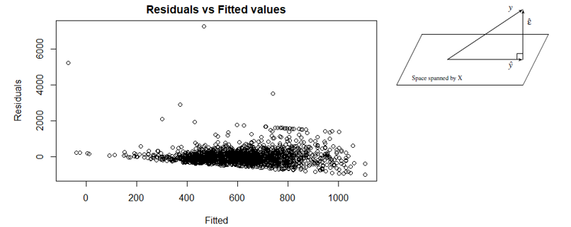

‘Geometric Reppresentation of Fitted vs Residuals’

### PART B

```
## [1] "X matrix"
```

```
##       [,1] [,2] [,3]
##  [1,]    1    2   -2
##  [2,]    1   -1   -2
##  [3,]    1    3   -2
##  [4,]    1    3    3
##  [5,]    1    2    3
##  [6,]    1    1    3
##  [7,]    1    0    0
##  [8,]    1    0    0
##  [9,]    1   -1    0
## [10,]    1    0    1
```

```
## [1] "B matrix"
```

```
##      [,1]
## [1,]    1
## [2,]   -1
## [3,]    2
```

```
## [1] "e matrix"
```

```
##             [,1]
##  [1,] -0.3524469
##  [2,]  1.8241308
##  [3,] -0.8731973
##  [4,]  1.0253696
##  [5,]  0.2389155
##  [6,] -1.9997165
##  [7,]  1.0447437
##  [8,]  0.5580184
##  [9,]  0.9245635
## [10,]  0.5327533
```

```
## [1] "Y matrix"
```

```
##             [,1]
##  [1,] -5.3524469
##  [2,] -0.1758692
##  [3,] -6.8731973
##  [4,]  5.0253696
##  [5,]  5.2389155
##  [6,]  4.0002835
##  [7,]  2.0447437
##  [8,]  1.5580184
##  [9,]  2.9245635
## [10,]  3.5327533
```

1.**β** esimtates

```
##           [,1]
## [1,]  1.606515
## [2,] -1.326545
## [3,]  1.949222
```

2. True variance of **ˆβ**

```
##              [,1]         [,2]         [,3]
## [1,]  0.139180672 -0.042016807 -0.003413866
## [2,] -0.042016807  0.050420168 -0.008403361
## [3,] -0.003413866 -0.008403361  0.027442227
```

3. Use the residuals to estimate σ2

```r
#sigma_hat^2 = e^t*e^/ (n-p) , RSS/df.residuals
#e= y-y^, y^ = xb^y => x(x^tx)^-1xty
e = sum((Y - X%*%b)^2) / (10-3)
e
```

```
## [1] 1.209809
```

4. Now create a new e and re-estimateβ.  
   Do this 1,000 times Save all the answers in memory.  
   Make a histogram of the 1,000 values ofˆβ1.  
   Do the same forˆβ2 andˆβ3.  
   Also calculate the variance for each ofthese.  
   Do your answers match with question 2?

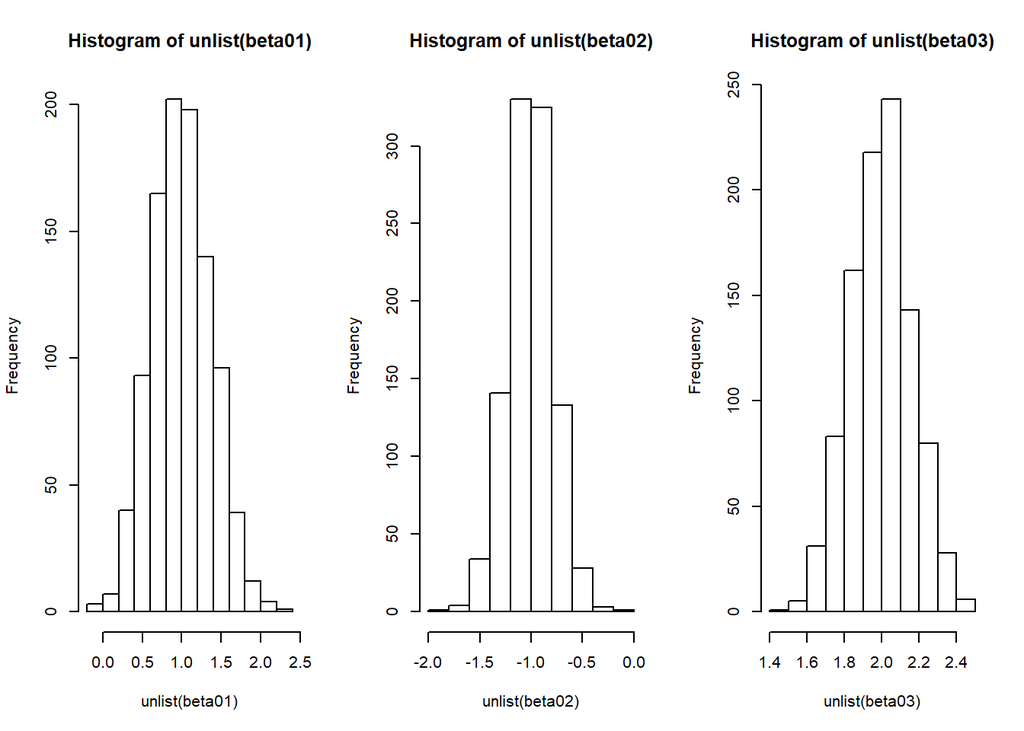

```r
beta01<- vector(mode = "list", length = 1000)
beta02<- vector(mode = "list", length = 1000)
beta03<- vector(mode = "list", length = 1000)

#1000 re-estimates for beta
for (i in 1:1000){

  #new e
E=matrix( rnorm(10*1,mean=0,sd=1), 10, 1)

#new Y
Y = X%*%B +E

#Calculate beta
xtxi <- solve(t(X) %*% X)
b = xtxi %*% t(X) %*% Y

#Store beta1
beta01[i] = b[1]
beta02[i] = b[2]
beta03[i] = b[3]

}

par(mfrow=c(1,3))
#Histogram of the 3 beta coefficients
hist(unlist(beta01))
hist(unlist(beta02))
hist(unlist(beta03))
```

```r
#Check variance of beta1 vs the variance of beta in question 2 (first entry) should be very close
var(unlist(beta01))
```

```
## [1] 0.1393694
```

```r
var(unlist(beta02))
```

```
## [1] 0.04989653
```

```r
var(unlist(beta03))
```

```
## [1] 0.02732745
```